# Module Report 2

490249332

11 September 2019

# Introduction and Data Cleaning

## Descriptions of Data

> Randomness and Representativity of Data

To decide if the data sample is random or not, we need to look at the source of this data, seeking demonstarations about how it is collected, how the sample data is selected and what population it is targetted. By investigating the survey design, sampling procedure, objects, tool, we can then assess its quality and representity, identify plausible errors and start our analysis and statistical inference. In the paper ‘A Methodology for Assessing Sample Representativeness’, the authors mantioned that randomness and the target population should be important to see if the data is reliable, as statistical inference can only be made to available population rather than the whole population(Ramsey and Hewitt, 2005). If randomness is not applied, no statistical inference can be made.

In our case, the survey is designed for students enrolled in DATA2002/2902. It may not be considered as random selected because the survey was not delivered to students randomly but students did it at ther discretion. Biased may be caused due to this design as discussed below.

> Potential Biases

There are 325 students enrolled in DATA2002/2902 in the second semester 2018. The response rate is not that high, hence the margin of error can be quite high. In this case, we tend to think the sample is not randomly chosen from the whole population. There will be need for a certain degreee of respondant rate. In our case, only 110 students respond and it is not enough to decide it is representative for a population of size 325. Representiveness and response rate are related. The larger the population size is, the lower response rate is required (Diego Graglia, 2019).

The data was collected through on-line survey on ed platform,it is likely to cause Non-response bias to sample results. Students who answered the survey are possibly those took DATA2002/2902 more seriously, joining campus life more actively and spend more time on study platform (ed). That might affect results to survey questions like: number of being member of school clubs, study time per week, time on social media platform and so on. Considering this issue, the sample can not be viewed as random or representative for the whole population.

Aside from collection bias, some survey questions are likely to cause measurement bias. For example: when people answering to the question: “how often do you floss your teeth(floss_frequency)” and “average hour spend on school work last semester(study)”, they may fail to answer accurately and truthfully due to memory. This can result in inaccurate conclusion. Other vaiable like “the last time to see dentist(dentist)” might also have measurement biases.

## First-step Data Cleaning

The codes are from Lab 2A and lec_10_ini.rmd.

```r
library(tidyverse)
library(janitor)
library(naniar)
library(kableExtra)
library('DT')
library(knitr)
library(ggpubr)

survey <- read_csv("DATA2X02 class survey (Responses) - Form responses 1.csv")
#Rename the columns
old_names = colnames(survey)
survey = survey %>%
  janitor::clean_names() %>%
  rename(postcode = postcode_of_where_you_live_during_semester,
         units = what_statistics_courses_have_you_taken,
         clubs = how_many_university_clubs_are_you_a_member_of,
         dentist = how_long_has_it_been_since_you_last_went_to_the_dentist,
         study = on_average_how_many_hours_per_week_did_you_spend_on_university_work_last_semester,
         social_media = what_is_your_favourite_social_media_platform,
         siblings = how_many_siblings_do_you_have,
         exercise = how_many_hours_a_week_do_you_spend_exercising,
         pet_growing_up = did_you_have_a_pet_growing_up ,
         live_with_parents = do_you_currently_live_with_your_parents,
         eye_colour = what_is_your_eye_colour,
         hrs_employed = how_many_hours_per_week_do_you_work_in_paid_employment,
         fav_season = what_is_your_favourite_season_of_the_year,
         shoe_size = what_is_your_shoe_size,
         height = how_tall_are_you,
         floss_frequency = how_often_do_you_floss_your_teeth,
         glasses = do_you_wear_glasses_or_contacts,
         handedness = what_is_your_dominant_hand,
         doneness = how_do_you_like_your_steak_cooked)
new_names = colnames(survey)


#Recode eyecolours
survey = survey %>% mutate(eye_colour = stringr::str_to_title(eye_colour),
    eye_colour = case_when(eye_colour == "Balack" ~ "Black", eye_colour ==
        "Hazelnut" ~ "Hazel", TRUE ~ eye_colour))
survey = survey %>%
  mutate(
    eye_colour = forcats::fct_lump_min(eye_colour, min = 2)
  )
survey %>% janitor::tabyl(eye_colour) %>% adorn_pct_formatting() %>% kable()

#Recode social media
survey %>%
  mutate(
    social_media = stringr::str_to_title(social_media),
    social_media = recode(social_media,
                          `Facebook Messenger` = "Facebook",
                          Fb = "Facebook",
                          `I Never Use Social Media.` = "None",
                          Ig = "Instagram"),
    social_media = forcats::fct_lump(social_media, n=7)
  ) %>%
  janitor::tabyl(social_media) %>% adorn_pct_formatting() %>% kable()
#Recode gender
survey = survey %>% mutate(recoded_gender = gendercodeR::recode_gender(gender))
survey %>% tabyl(recoded_gender) %>% kable()

#Recode height
survey = survey %>%
  mutate(
    height = case_when(
      height > 230 ~ NA_real_,
      height < 1.1 ~ NA_real_,
      height < 2.30 ~ height*100,
      TRUE ~ height
    )
  )
survey %>% tabyl(height) %>% kable()


#Recode exercise

survey = survey %>%
  mutate(
    exercise = as.numeric(exercise),
    exercise = case_when(
      exercise > 24*7 ~ NA_real_,
      TRUE ~ exercise
    )
  )
survey %>% tabyl(exercise) %>% kable()

glimpse(survey)
```

# Analysis

We begin analysis of the data in certain questions below. The significance level we use in tests throught all this section in this report would be
$$\alpha = 0.05$$
.

## Exercises and Diet

In this analysis, we will focus on the difference of time spending on exericises between students who eat red meat or not. In order to do this, we need to modify the data a little bit. Some summeries are as follows.

```r
#Classify students who eat red meat or not
survey = survey%>%
  mutate(
    eat_red_meat = as.factor(doneness),
    eat_red_meat = forcats::fct_collapse(eat_red_meat,
                                           No = c("I don't eat red meat"),
                                           Yes = c("Medium", "Medium-rare", "Medium-well done",'Rare','Well done')),
    eat_red_meat = as.vector(eat_red_meat)
  )

#Working on dataframe
redexercise =survey%>%
  select(exercise,eat_red_meat)%>%
  filter(eat_red_meat == 'Yes'|eat_red_meat == 'No')

summ1 = redexercise%>%
  group_by(eat_red_meat)%>%
  drop_na()%>%
  summarise(
    Mean = mean(exercise),
            SD = sd(exercise),
            n = n())
summ1%>%
  kable() %>%
  kable_styling(bootstrap_options = c("hover", "condensed"), full_width = TRUE)
```

| eat_red_meat | Mean | SD | n |
| --- | --- | --- | --- |
| No | 5.0000 | 4.690416 | 7 |
| Yes | 4.0125 | 3.866192 | 100 |

> Data Visualisation:

Visualising the data makes the features and summaries of data more easier to identify. Here we do the $gglpot()$ and $boxplot()$. The main purpose of doing this is to check if the $\textbf{Normality Assumption}$ of parametric tests or $\textbf{Symmetric Assumption}$ of non-parametric tests is satisfied.

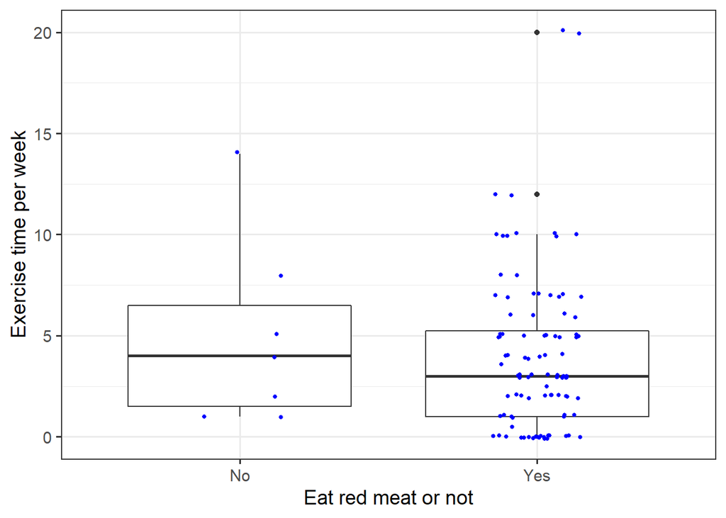

```r
library("ggplot2")
ggplot(redexercise, aes(x = eat_red_meat, y = exercise)) +
  geom_boxplot() +
  geom_jitter(width=0.15, size = 1, colour = "blue") +
  theme_bw(base_size = 14) +
  labs(x = "Eat red meat or not", y = "Exercise time per week")
```

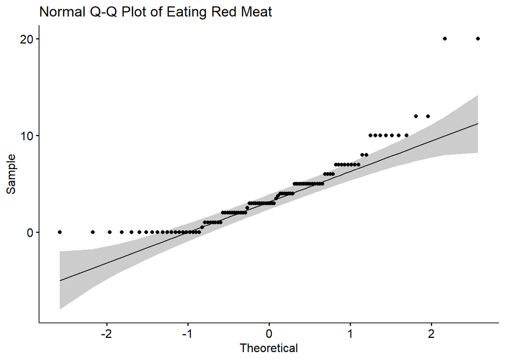

```r
c1 = redexercise%>%
  drop_na()%>%
  filter(eat_red_meat == 'Yes')%>%
  select(exercise)%>%
  pull(exercise)

c2 = redexercise%>%
  drop_na()%>%
  filter(eat_red_meat == 'No')%>%
  pull(exercise)

ggqqplot(c1,main = "Normal Q-Q Plot of Eating Red Meat")
```

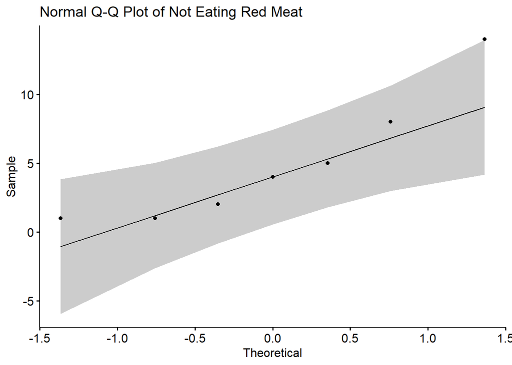

```r
ggqqplot(c2,main = "Normal Q-Q Plot of Not Eating Red Meat")
```

```r
#Shapiro.test for Testing Normality
y_m = c(shapiro.test(c1)$p.value,shapiro.test(c2)$p.value)
x_m = c("Eat red meat", "Do not eat red meat")
y_m.mat = matrix(y_m,1,2)
colnames(y_m.mat) = x_m
rownames(y_m.mat) = "p-value"
y_m.mat%>%
  kable() %>%
  kable_styling(bootstrap_options = c("hover", "condensed"), full_width = TRUE)
```

|  | Eat red meat | Do not eat red meat |
| --- | --- | --- |
| p-value | 0 | 0.1465892 |

According to the boxplot, we can see the shapes of two plots are similar but the means are different. They does not seem symmetric as well.

According to the qqplot for checking normality, we can see in both graphs there is a departure at ends of the line. The points look disperse, especially when sample size is small.

According to the results of shapiro.tests, the p-values of sample of eating red meat is extremely small and rounded to 0, indicating no evidence of normality. The grey area shows the 95% Confidence Interval of values along the regression line @.

We may not assume the samples are from normal distribution, but it is comfortable to recognize that they are from the distribution differed by a shift.

> Wilcoxon Rank-sum Test

**Hypothesis:**

$$H_0 = \text{ The difference of the time spending on exericises per week between students who eat red meat or not is 0 } (\mu_{X}=\mu_{Y})$$
$$H_1 = \text{ The difference of the time spending on exericises per week between students who eat red meat or not is not 0 } (\mu_{X}\neq\mu_{Y})$$
**Assumptions and Check of Eligibility:**

$$\text{The two groups of data (X,Y) are independent and follow the same distribution but differ by a shift.}$$

Here we apply wilcoxon rank sum test. We don’t choose welch two-sample t-test because the distibution of red meat sample doesn’t follow normal distribution after checking normality by shapiro.test. We can also see from boxplot and qqplot of data the distributions of two groups seem not symmetric or normal, but only look similar in shape, which would be indications for a similar distribution with shifts. The sample size between group not eating red meat and eating red meat has a great discrepancy. In addition, the sample size of group not eating red meat is only 7, which is quite small and is not eligible to apply Central Limit Theorem to consider it as a normal distribution.

**Test Statistics and p-value:**

Calculating manually using formula:

The test statistics turns out to be 304.5, and p-value is 0.5740.

```r
datE = data.frame(
  exercise = c(c1,c2),
  Eat_red_meat = c(rep("Yes", length(c1)),
             rep("No", length(c2)))
)
datE = datE %>% mutate(r = rank(exercise))
sum_dat = datE %>%
  group_by(Eat_red_meat) %>%
  summarise(n = n(),
            w = sum(r)
  )
n_A = sum_dat$n[sum_dat$Eat_red_meat == "Yes"]
n_B = sum_dat$n[sum_dat$Eat_red_meat == "No"]
w_A = sum_dat$w[sum_dat$Eat_red_meat == "Yes"]
# using the sums of the A sample
ew_A = n_A * (n_A + n_B + 1)/2
minw_A = n_A * (n_A + 1)/2
#c(minw_A, w_A, ew_A) # w_A < ew_A
# looking in the lower tail

c(w_A - minw_A, 2*pwilcox(w_A - minw_A, n_A, n_B))
```

```
## [1] 304.500000   0.574085
```

Using embedded function $wilcox.test()$:

The test statistics turns out to be 304.5, and p-value is 0.5681.

```r
wilcox.test(c1, c2)
```

```
##
##  Wilcoxon rank sum test with continuity correction
##
## data:  c1 and c2
## W = 304.5, p-value = 0.5681
## alternative hypothesis: true location shift is not equal to 0
```

**Conclusion:**

In both methods the test statistics are the same and the p-values are very similar. The p-value is around 0.57 and is quite large indicating no evidence against $H_0$. Hence, we do not reject $H_0$ and there is no difference of the time spending on exericises per week between students who eat red meat or not.

## Exercise and Clubs

In this part of study we are try to analysing if there is any evidence that the weekly exercise time of students who participate in more than 3 univeristy clubs is different to those who don隆炉t. Some summeries are as follows.

```r
clubex=survey%>%
  select(exercise,clubs)
clubex = clubex%>%
  drop_na()%>%
  group_by (clubs >3)
summ2 = clubex%>%
  summarise(
    Mean = mean(exercise),
            SD = sd(exercise),
            n = n())%>%
  rename (Number_of_clubs = `clubs > 3`)%>%
  mutate(
    Number_of_clubs = as.character(Number_of_clubs),
    Number_of_clubs = recode(Number_of_clubs,
    `TRUE` = 'More than 3',
    `FALSE` = 'Less or equal than 3')
  )



summ2%>%
  kable() %>%
  kable_styling(bootstrap_options = c("hover", "condensed"), full_width = TRUE)
```

| Number_of_clubs | Mean | SD | n |
| --- | --- | --- | --- |
| Less or equal than 3 | 4.260309 | 4.012013 | 97 |
| More than 3 | 2.300000 | 2.057507 | 10 |

> Data Visualisation

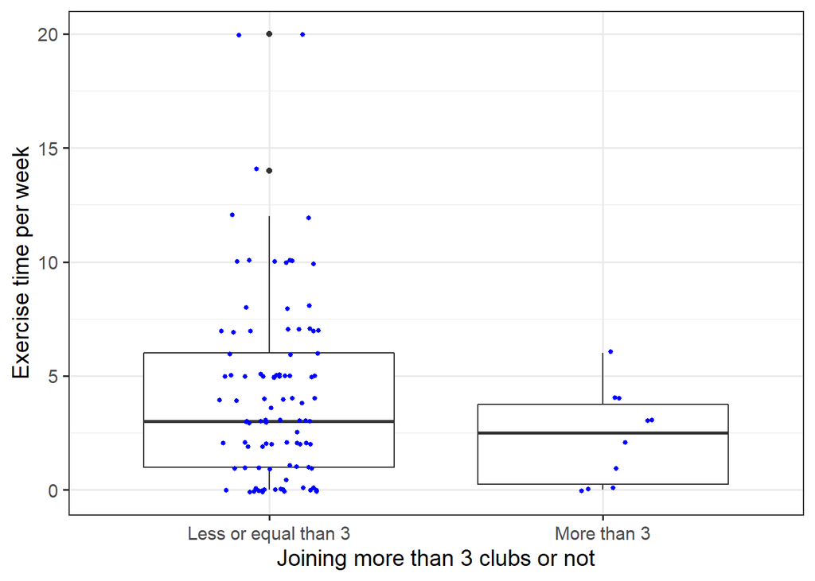

```r
ggplot(clubex, aes(x = `clubs > 3`, y = exercise)) +
  geom_boxplot() +
  geom_jitter(width=0.15, size = 1, colour = "blue") +
  theme_bw(base_size = 14) +
  scale_x_discrete(breaks=c("TRUE","FALSE"),
        labels=c("More than 3", "Less or equal than 3"))+
  labs(x = "Joining more than 3 clubs or not", y = "Exercise time per week")
```

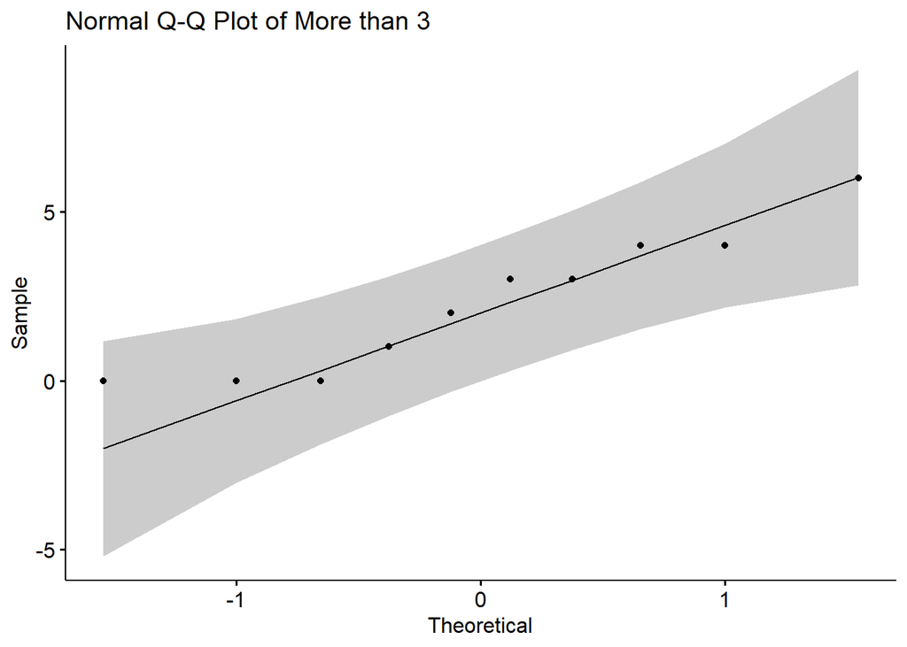

```r
c1 = clubex%>%
  drop_na()%>%
  filter(clubs > 3)%>%
  ungroup() %>%
  select(exercise)%>%
  pull(exercise)


c2 = clubex%>%
  drop_na()%>%
  filter(clubs <= 3)%>%
  ungroup() %>%
  pull(exercise)
ggqqplot(c1,main = "Normal Q-Q Plot of More than 3")
```

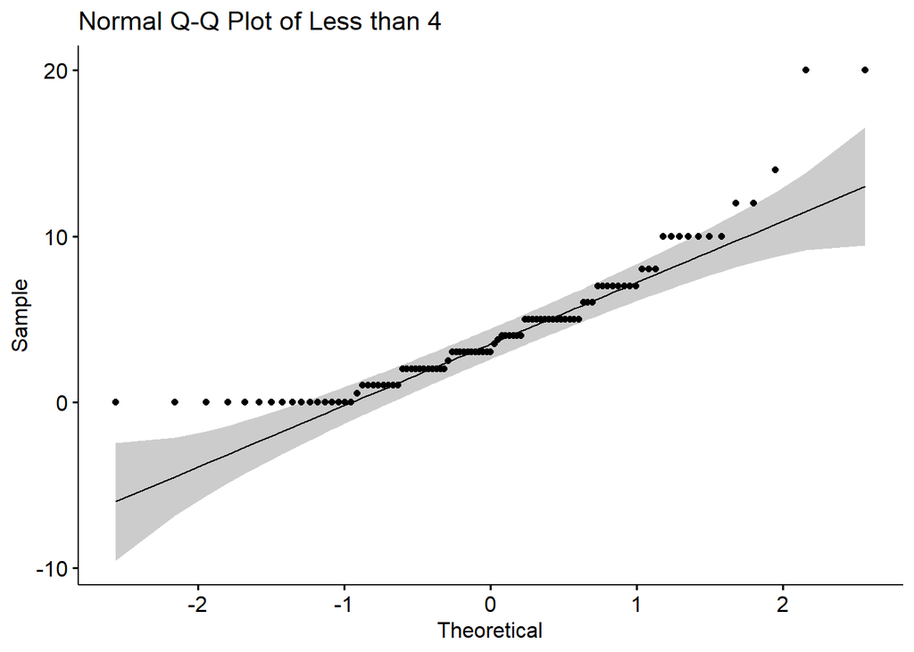

```r
ggqqplot(c2,main = "Normal Q-Q Plot of Less than 4")
```

```r
#Shapiro.test for Testing Normality
y_m = c(shapiro.test(c1)$p.value,shapiro.test(c2)$p.value)
x_m = c("More than 3 clubs", "Less or equal than 3 clubs")
y_m.mat = matrix(y_m,1,2)
colnames(y_m.mat) = x_m
rownames(y_m.mat) = "p-value"
y_m.mat%>%
  kable() %>%
  kable_styling(bootstrap_options = c("hover", "condensed"), full_width = TRUE)
```

|  | More than 3 clubs | Less or equal than 3 clubs |
| --- | --- | --- |
| p-value | 0.3098405 | 0 |

According to the boxplot, we can see the shapes of two plots are quite different. They does not seem symmetric as well. The variances of two samples also differ a lot.

According to the qqplot for checking normality, we can see in the graphs there is a departure at ends of the line. The points look disperse, especially when sample size is large.

According to the results of shapiro.tests, the p-values of sample of less-than-3-club is extremely small and rounded to 0, indicating no evidence of normality.

We may not assume the samples are from normal distribution and also from a symmetric distribution. In this case, we shall use wilcoxon rank-sum test as it is quite robust.

> Wilcoxon Rank-sum test

**Hypothesis:**

**Assumptions and Check of Eligibility:**

$$Assumption: \text{The two groups of data (X,Y) are independent and follow the same distribution but differ by a shift.}$$
In this case, we apply wilcox rank sum test due to its robustness. We don’t choose welch two-sample t-test because the assumptions of two sample t-test do not meet. The distibution of less-or-equal-than-3 sample group doesn’t follow normal distribution after checking normality by shapiro.test and investigating the boxplot and qqplot. The distributions of two groups seem not symmetric at all. Additionally, the sample size between groups of less-than-or-equal-to-3-clubs and more-than-3-clubs has a huge discrepancy.The sample size of group more-than-3-clubs is only 10, which is quite small and is not eligible to apply Central Limit Theorem to consider it as a normal distribution. In addition, though the sample size of group of less-than-or-equal-to-3-clubs is large, it seems its distribution is nomarl and is failed in normality test.

**Test Statistics and p-value:**

Calculating manually using formula:

The test statistics turns out to be 346.5, and p-value is 0.14.

```r
datE = data.frame(
  exercise = c(c1,c2),
  Number_of_clubs= c(rep("More than 3", length(c1)),
             rep("Less or equal than 3", length(c2)))
)
datE = datE %>% mutate(r = rank(exercise))
sum_dat = datE %>%
  group_by(Number_of_clubs) %>%
  summarise(n = n(),
            w = sum(r)
  )
n_A = sum_dat$n[sum_dat$Number_of_clubs == "More than 3"]
n_B = sum_dat$n[sum_dat$Number_of_clubs == "Less or equal than 3"]
w_A = sum_dat$w[sum_dat$Number_of_clubs == "More than 3"]
# using the sums of the A sample
ew_A = n_A * (n_A + n_B + 1)/2
minw_A = n_A * (n_A + 1)/2
#c(minw_A, w_A, ew_A) # w_A < ew_A
# looking in the lower tail
c(w_A - minw_A, 2*pwilcox(w_A - minw_A, n_A, n_B))
```

```
## [1] 346.5000000   0.1399553
```

Using embedded function $wilcox.test()$:

The test statistics turns out to be 346.5, and p-value is 0.137.

```r
wilcox.test(c1, c2)
```

```
##
##  Wilcoxon rank sum test with continuity correction
##
## data:  c1 and c2
## W = 346.5, p-value = 0.137
## alternative hypothesis: true location shift is not equal to 0
```

**Conclusion:**

In both methods the test statistics are the same and the p-values are very similar. The p-value is around 0.14 and it islarger than 0.05 indicating no evidence against $H_0$ at 5% siginificance level. Hence, we do not reject $H_0$ and there is no difference of the time spending on exericises per week between students join more than 3 clubs or not.

## Study Time and Living with Parents

We would like to know if there is any evidence that students who live with their parents study more hours per week than students who do not live with. Summaries are as follows.

```r
studypa =survey%>%
  select(study,live_with_parents)%>%
  filter(live_with_parents == 'Yes'|live_with_parents == 'No')%>%
  filter(study<98) # suppose a student sleep at least for 8 hours a day in one week and spend at least 2 hours eating and relaxing...So we get rid of some irregular data...orz


summ3 = studypa%>%
  drop_na()%>%
  group_by (live_with_parents)%>%
  summarise(
    Mean = mean(study),
            SD = sd(study),
            n = n())
summ3%>%
  kable() %>%
  kable_styling(bootstrap_options = c("hover", "condensed"), full_width = TRUE)
```

| live_with_parents | Mean | SD | n |
| --- | --- | --- | --- |
| No | 27.22414 | 14.36131 | 58 |
| Yes | 26.91489 | 14.06326 | 47 |

> Data Visualisation

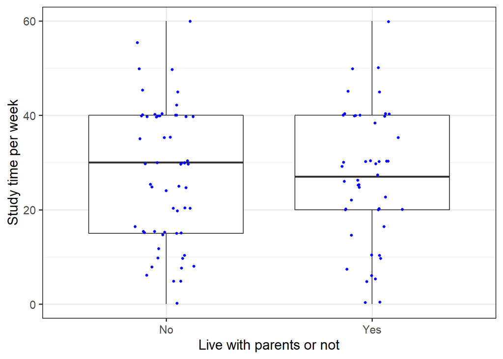

```r
ggplot(studypa, aes(x = live_with_parents, y = study)) +
  geom_boxplot() +
  geom_jitter(width=0.15, size = 1, colour = "blue") +
  theme_bw(base_size = 14) +
  labs(x = "Live with parents or not", y = "Study time per week")
```

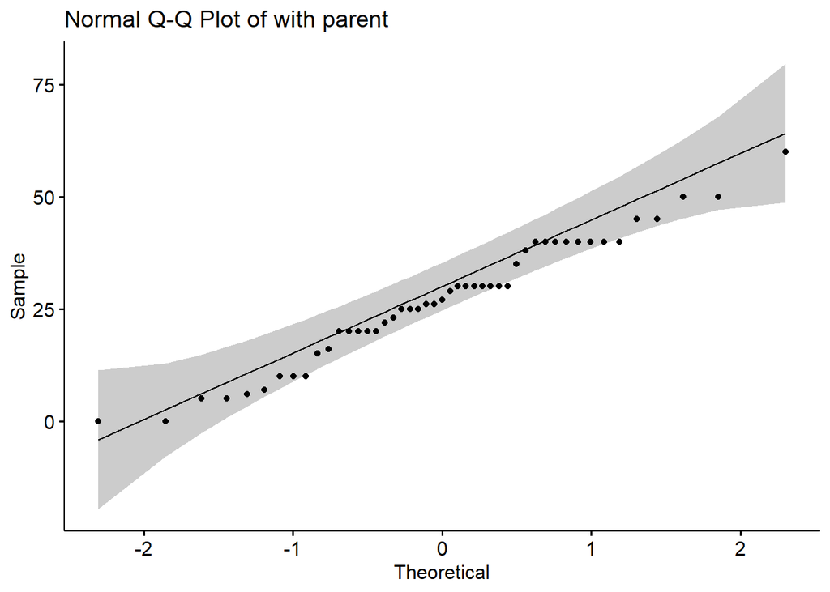

```r
c1 = studypa%>%
  drop_na()%>%
  filter(live_with_parents == 'Yes')%>%
  select(study)%>%
  pull(study)

c2 = studypa%>%
  drop_na()%>%
  filter(live_with_parents == 'No')%>%
  pull(study)
ggqqplot(c1,main = "Normal Q-Q Plot of with parent")
```

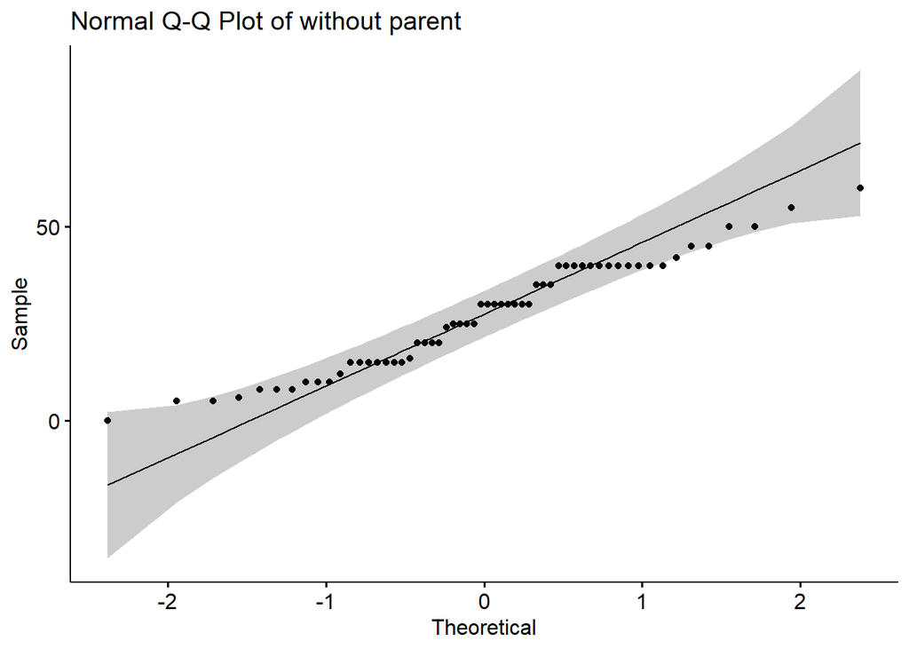

```r
ggqqplot(c2,main = "Normal Q-Q Plot of without parent")
```

```r
#Shapiro.test for Testing Normality
y_m = c(shapiro.test(c1)$p.value,shapiro.test(c2)$p.value)
x_m = c("More than 3 clubs", "Less or equal than 3 clubs")
y_m.mat = matrix(y_m,1,2)
colnames(y_m.mat) = x_m
rownames(y_m.mat) = "p-value"
y_m.mat%>%
  kable() %>%
  kable_styling(bootstrap_options = c("hover", "condensed"), full_width = TRUE)
```

[output not shown]

According to the boxplot, we can see the shapes of two plots are a little bit different. They seem symmetric but not that much. The points are spreaded randomly in the boxplots and it is still OK for us to say they meet the symmetric assumption. We may not assume they are of homogeneity.

According to the qqplot for checking normality, we can see in the graphs that the points are mostly lying in the 95% confidence interval. The points stay close to the line, indicating fitness of normal line.

According to the results of shapiro.tests, the p-values of two samples are both larger than 0.05, indicating evidence of normality. We may conclude they are normally distributed.

We can assume the samples are from normal distribution. In this case, we can performa two-sample t test.

> Two Sample t-test

**Hypothesis:**

$$H_0 = \text{ There is no difference of study hours per week between students who live with their parents with who don隆炉t live with }(\mu_{X} =\mu_{Y})$$
$$H_1 = \text{ students who live with their parents study more hours per week than students who don隆炉t live with}(\mu_{X} > \mu_{Y})$$

**Assumptions and Check of Eligibility:**

$$Assumption: \text{The two groups of data (X,Y) are independent and follow normal distribution.}$$
In this case, we apply two sample t-test. According to normality check by shapiro.test and investigation of the boxplot and qqplot. The distributions of two groups seem symmetric and normal. Additionally, the sample size between groups is similar and >30, which is suitably large for a normal assumption by CLT.

**Test Statistics and p-value:**

Calculating manually using formula:

The test statistics turns out to be -0.11, and p-value is 0.5440.

```r
nY = as.numeric(summ3[2,4])
nN = as.numeric(summ3[1,4])
sY = as.numeric(summ3[2,3])
sN = as.numeric(summ3[1,3])
sP = sqrt(((nY - 1) * sY^2 + (nN - 1) * sN^2)/
            (nY + nN - 2))
mY = as.numeric(summ3[2,2])
mN = as.numeric(summ3[1,2])
deg_free = nY+nN-2

t0 = (mY - mN)/(sP * sqrt(1/nY + 1/nN))
p_val = pt(abs(t0), deg_free)
c(t0, p_val)
```

```
## [1] -0.1107380  0.5439802
```

Using embedded function $t.test()$:

The test statistics turns out to be -0.11, and p-value is 0.544.

```r
t.test(c1,c2, alternative = "greater", var.equal = TRUE)
```

```
##
##  Two Sample t-test
##
## data:  c1 and c2
## t = -0.11074, df = 103, p-value = 0.544
## alternative hypothesis: true difference in means is greater than 0
## 95 percent confidence interval:
##  -4.944314       Inf
## sample estimates:
## mean of x mean of y
##  26.91489  27.22414
```

**Conclusion:**

In both methods the test statistics are the same and the p-values are very similar. The p-value is around 0.54 and it is quite large indicating no evidence against $H_0$ at 5% siginificance level. Hence, we do not reject $H_0$ and there is no difference of the time spending on study per week between students who live with parents or not.

## Additional Question 1: Does Siblings matter?

Does having or not having siblings affect study, social activity(clubs), exercise, work(balance life and work) of students? Being the only child in family or not is a heated topic in China. Most students in China is the only child in their family due to policy restriction. We want to discorver if there is some difference between student lifes of who are the only child in their family or not. In this case, we apply two sample multivariate test of means. Since we are compraing multiple means of groups of twp samples, it is suitable to use a multivariate test.

**Hypothesis:**

$$H_0 = \text{ There is no difference of study, social activity(clubs), exercise, work(balance life and work) between students has siblings or not }(\mu_{\textbf{X}} =\mu_{\textbf{Y}})$$
$$H_1 = \text{ There is difference of study, social activity(clubs), exercise, work(balance life and work) between students has siblings or not }(\mu_{\textbf{X}} \neq \mu_{\textbf{Y}})$$

**Assumptions and Check of Eligibility:**

$$Assumption: \text{The two groups of data } (\textbf{X},\textbf{Y}) \text{ are independent and follow a multivariate normal distribution}$$
$$\text{ where } \textbf{X},\textbf{Y} \text{ are random vectors corresponding to two samples}$$
We have not learnt how to check assumption of multivatiate normal. Symmetry? In this case, since the sample size is large, we asumption is satisfied by CLT.

**Test Statistics and p-value:**

Using embedded function $HotellingsT2$:

```r
data = survey
##data cleaning
data7 = data %>%
  filter(siblings >= 0& !(exercise >168) & !(study >168)& !(clubs > 30) & !(hrs_employed > 168)) %>% #168 is the total hour in one week
  dplyr::select(siblings,study,clubs,exercise,hrs_employed) %>%
  mutate(one_child = (siblings == 0)) %>% group_by(one_child) %>%
  dplyr::select(-siblings) %>% as.data.frame()
dat_one_c = data7 %>% filter(one_child == TRUE) %>% dplyr::select(-one_child)
dat_s = data7 %>% filter(one_child == FALSE) %>% dplyr::select(-one_child)

ICSNP::HotellingsT2(dat_one_c, dat_s, test = "f")
```

```
##
##  Hotelling's two sample T2-test
##
## data:  dat_one_c and dat_s
## T.2 = 1.4397, df1 = 4, df2 = 99, p-value = 0.2266
## alternative hypothesis: true location difference is not equal to c(0,0,0,0)
```

```r
### Whether having siblings is  not a big factor that impacts students life,study and work
```

## Additional Question 2: Employment time and Study time: Permutation test

```r
workstudy =survey%>%
  select(hrs_employed ,study)%>%
  filter(study < 98)%>%
  filter(study > 40|study< 15)%>%
  filter(hrs_employed<90 & hrs_employed != 0)# suppose a student sleep at least for 8 hours a day, eat and study for 2.5 hours and only count for non-zero values for hrs_employed

summ4 = workstudy%>%
  drop_na()%>%
  group_by (study>40)%>%
  summarise(
    Mean = mean(hrs_employed),
            SD = sd(hrs_employed),
            n = n())%>%
  rename (study_time = `study > 40`)%>%
  mutate(
    study_time = as.character(study_time),
    study_time = recode(study_time,
    `TRUE` = 'More than 40',
    `FALSE` = 'Less than 15')
  )

summ4%>%
  kable() %>%
  kable_styling(bootstrap_options = c("hover", "condensed"), full_width = TRUE)
```

| study_time | Mean | SD | n |
| --- | --- | --- | --- |
| Less than 15 | 12.88889 | 8.767047 | 9 |
| More than 40 | 9.87500 | 6.174544 | 8 |

> Data Visualisation

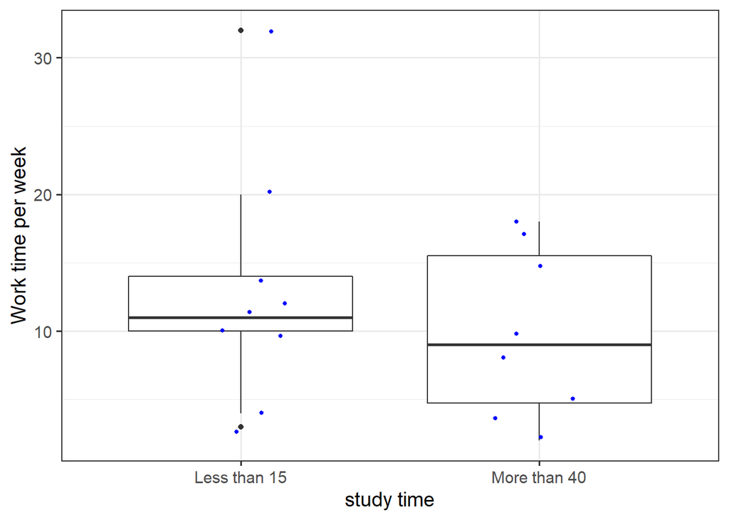

```r
ggplot(workstudy, aes(x = study > 40, y = hrs_employed)) +
  geom_boxplot() +
  geom_jitter(width=0.15, size = 1, colour = "blue") +
  theme_bw(base_size = 14) +
  scale_x_discrete(breaks=c("TRUE","FALSE"),
        labels=c("More than 40", "Less than 15"))+
  labs(x = "study time", y = "Work time per week")
```

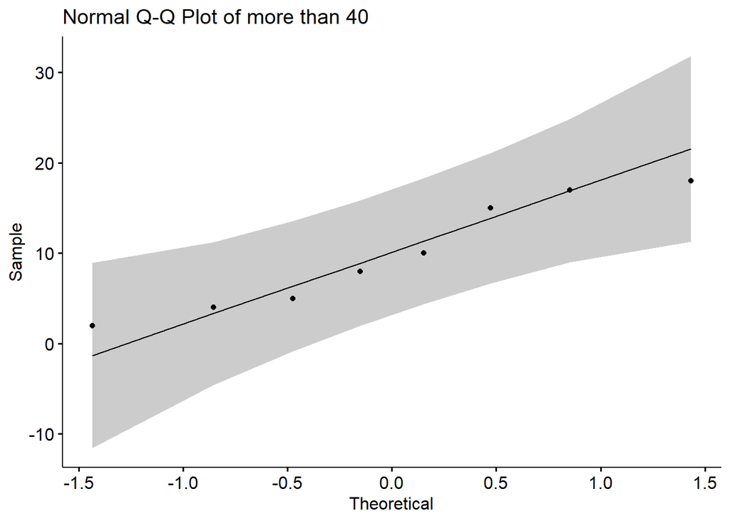

```r
par(mfrow = c(1,2), cex = 0.8, mar = c(4,4,1.1,0.5))

c1 = workstudy%>%
  drop_na()%>%
  filter(study>40)%>%
  select(hrs_employed)%>%
  pull(hrs_employed)

c2 = workstudy%>%
  drop_na()%>%
  filter(study < 15)%>%
  pull(hrs_employed)
ggqqplot(c1,main = "Normal Q-Q Plot of more than 40")
```

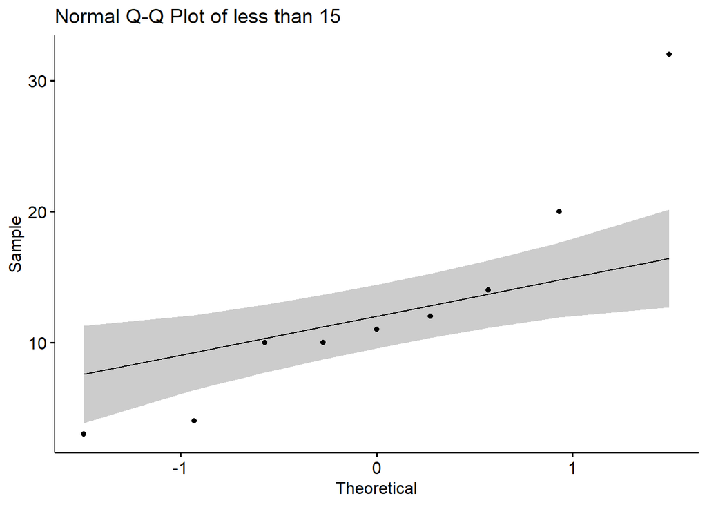

```r
ggqqplot(c2,main = "Normal Q-Q Plot of less than 15")
```

```r
#Shapiro.test for Testing Normality
y_m = c(shapiro.test(c1)$p.value,shapiro.test(c2)$p.value)
x_m = c("More than 40 hours", "Less than 15 hours")
y_m.mat = matrix(y_m,1,2)
colnames(y_m.mat) = x_m
rownames(y_m.mat) = "p-value"
y_m.mat%>%
  kable() %>%
  kable_styling(bootstrap_options = c("hover", "condensed"), full_width = TRUE)
```

|  | More than 40 hours | Less than 15 hours |
| --- | --- | --- |
| p-value | 0.418294 | 0.1516721 |

According to the boxplot, we can see the shapes of two plots are different. They seem symmetric but not that much but are from different distributions. The points are spreaded randomly in the boxplots and it is still OK for us to say they meet the symmetric assumption. We may not assume they are of homogeneity.

According to the qqplot for checking normality, we can see in the graph of more-than-40-hours that the points are mostly lying in the 95% confidence interval, while in the other one the points depart at ends of the normal line. We then perform the shapiro.test to test for normality.

According to the results of shapiro.tests, the p-values of two samples are both larger than 0.05, indicating evidence of normality. We may conclude they are normally distributed.

We can assume the samples are from normal distribution. In this case, we can perform a two-sample t test.

> Two Sample t-test

**Hypothesis:**

$$H_0 = \text{ There is no difference of work hours per week between students who study more than 40 hours per week and less than 15 hours per week }(\mu_{X} =\mu_{Y})$$
$$H_1 = \text{ There is difference of work hours per week between students who study more than 40 hours per week and less than 15 hours per week }(\mu_{X} \neq \mu_{Y})$$

**Assumptions and Check of Eligibility:**

$$Assumption: \text{The two groups of data (X,Y) are independent and follow normal distribution.}$$

In this case, we apply two sample t-test. According to normality check by shapiro.test and investigation of the boxplot and qqplot. The distributions of two groups seem symmetric and normal.

**Test Statistics and p-value:**

Caculating manually using formula:

The test statistic is reported as -0.809, and p-value is 0.431.

```r
nY = as.numeric(summ4[2,4])
nN = as.numeric(summ4[1,4])
sY = as.numeric(summ4[2,3])
sN = as.numeric(summ4[1,3])
sP = sqrt(((nY - 1) * sY^2 + (nN - 1) * sN^2)/(nY + nN - 2))
mY = as.numeric(summ4[2,2])
mN = as.numeric(summ4[1,2])
deg_free = nY+nN-2

t0 = (mY - mN)/(sP * sqrt(1/nY + 1/nN))
p_val = 2*(1-pt(abs(t0), deg_free))
c(t0, p_val)
```

```
## [1] -0.8089813  0.4311712
```

Using embedded function $t.test()$:

The test statistic is reported as -0.809, and p-value is 0.4312.

```r
t.test(c1,c2, var.equal = TRUE)
```

```
##
##  Two Sample t-test
##
## data:  c1 and c2
## t = -0.80898, df = 15, p-value = 0.4312
## alternative hypothesis: true difference in means is not equal to 0
## 95 percent confidence interval:
##  -10.954680   4.926903
## sample estimates:
## mean of x mean of y
##   9.87500  12.88889
```

```r
tt = t.test(c1,c2, var.equal = TRUE)
```

> Permutation Test

Permutation test is quite robust. It relaxes lots of assumptions and only assume the variables are exchangeable. It is quite suitbble for conditions when the sample size is small. We would like to know if its results is consistent with the ones from two_sample t.test.

**Hypothesis:**

$$H_0 = \text{ There is no difference of work hours per week between students who study more than 40 hours per week and less than 15 hours per week }(\mu_{X} =\mu_{Y})$$
$$H_1 = \text{ There is difference of work hours per week between students who who study more than 40 hours per week and less than 15 hours per week }(\mu_{X} \neq \mu_{Y})$$

**Assumptions and Check of Eligibility:**

$$Assumption: \text{The two groups of data (X,Y) are exchangable under null hypothesis.}$$

Since permutation tests are quite robust, it is suitablr that we assume under the null hypothesis, the two group of random variables are exchangeable.

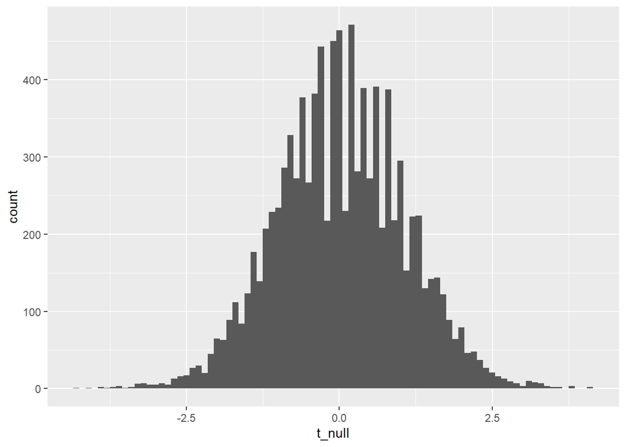

```r
dat = workstudy%>%
  drop_na()%>%
  group_by (study > 40)%>% filter(`study > 40` %in% c("TRUE", "FALSE"))
set.seed(2333)
B = 10000 # number of permuted samples we will consider
permuted_dat = dat # make a copy of the data
t_null = vector("numeric", B) # initialise outside loop
for(i in 1:B) {
  permuted_dat$`study > 40` = sample(dat$`study > 40`) # this does the permutation
  t_null[i] = t.test(hrs_employed ~ `study > 40`, data = permuted_dat)$statistic
}
data.frame(t_null) %>%
  ggplot(aes(x = t_null)) +
  geom_histogram(binwidth = 0.1) +
  theme_linedraw(base_size = 14)+
  theme_gray()
```

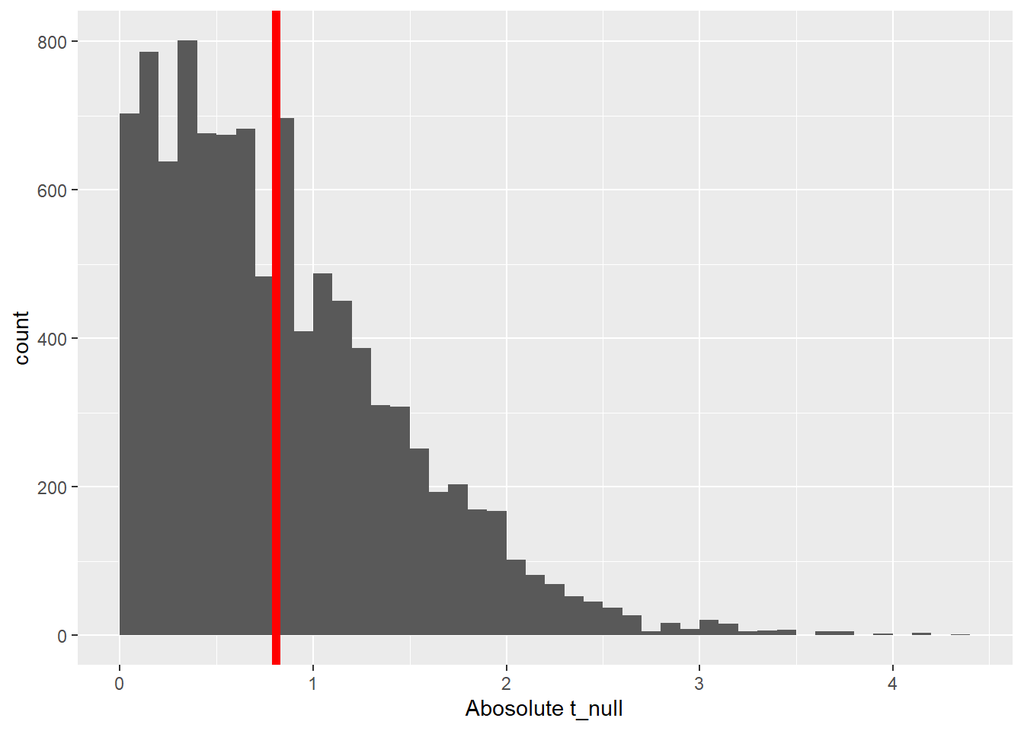

```r
data.frame(abs_t_null = abs(t_null)) %>%
  ggplot(aes(x = abs_t_null)) +
  geom_histogram(binwidth = 0.1,
                 boundary = 0) +
  labs(x = 'Abosolute t_null')+
  theme_linedraw(base_size = 14) +
  geom_vline(xintercept = abs(tt$statistic),
             col = "red", lwd = 2) +
  theme_gray()
```

```r
mean(abs(t_null) >= abs(tt$statistic))
```

```
## [1] 0.4527
```

**Test Statistics and p-value:**

Simulating by permutaion:

The test statistic is not reported, and p-value is 0.4527.

## References

respondants needed

https://www.surveymonkey.com/curiosity/how-many-people-do-i-need-to-take-my-survey/